# R_excercise

2023-05-12

## Read iris data

```r
Iris <- read.csv('./Iris.csv')
class(Iris)
```

```
## [1] "data.frame"
```

```r
head(Iris)
```

```
##   Id SepalLengthCm SepalWidthCm PetalLengthCm PetalWidthCm     Species
## 1  1           5.1          3.5           1.4          0.2 Iris-setosa
## 2  2           4.9          3.0           1.4          0.2 Iris-setosa
## 3  3           4.7          3.2           1.3          0.2 Iris-setosa
## 4  4           4.6          3.1           1.5          0.2 Iris-setosa
## 5  5           5.0          3.6           1.4          0.2 Iris-setosa
## 6  6           5.4          3.9           1.7          0.4 Iris-setosa
```

# Scatter plot with x-axis: Sepal.Length and y-axis: Sepal.Width, and the species should be shown in different colors

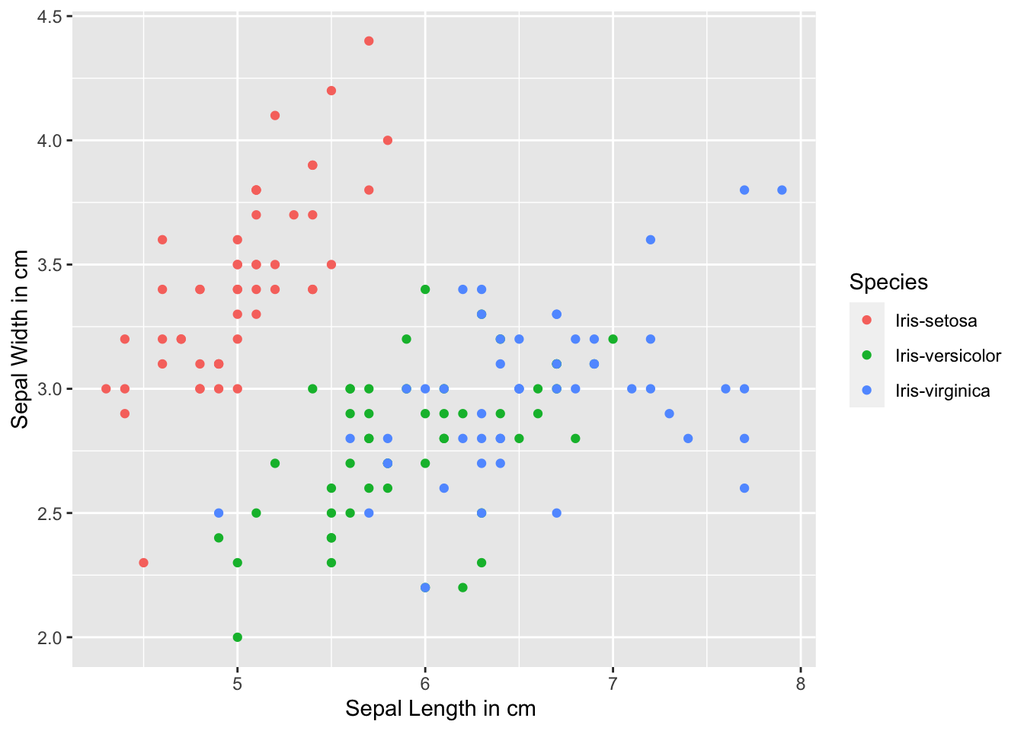

```r
ggplot(Iris, aes(x = SepalLengthCm, y = SepalWidthCm, color = Species)) +
  geom_point() +
  labs(x = "Sepal Length in cm ", y = "Sepal Width in cm")
```

## Add regression line for the previous plot with the whole dataset (regardless of the species)

The argument aes(group = 1) in the geom_smooth() function is used to indicate that all data points in the dataset should be considered as a single group when performing the regression.

### Linear model

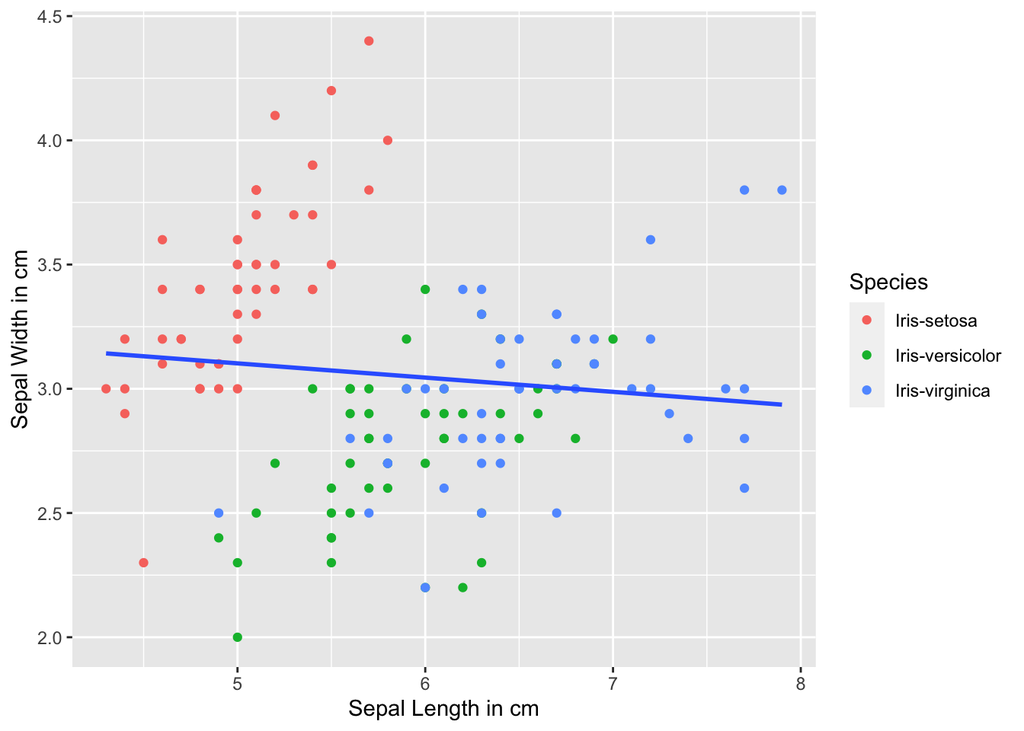

```r
ggplot(Iris, aes(x = SepalLengthCm, y = SepalWidthCm)) +
  geom_point(aes(color = Species, group = Species)) +
  geom_smooth(method = lm, se = FALSE, aes(group = 1)) +
  labs(x = "Sepal Length in cm", y = "Sepal Width in cm")
```

### Method auto

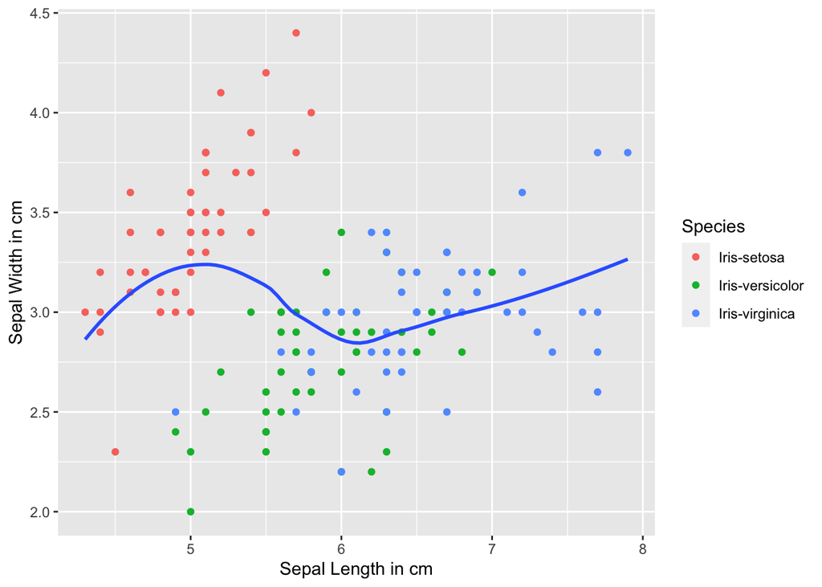

```r
ggplot(Iris, aes(x = SepalLengthCm, y = SepalWidthCm)) +
  geom_point(aes(color = Species, group = Species)) +
  geom_smooth(method = 'auto', se = FALSE, aes(group = 1)) +
  labs(x = "Sepal Length in cm", y = "Sepal Width in cm")
```

## Pearson correlation

```r
cor(iris$Sepal.Length, iris$Sepal.Width)
```

```
## [1] -0.1175698
```

Since the correlation coefficient is negative and close to zero, it indicates a weak, negative correlation between sepal length and sepal width in the data set.

## Make the boxplot for Petal.Width with 3 species separately in the x-axis in different colors

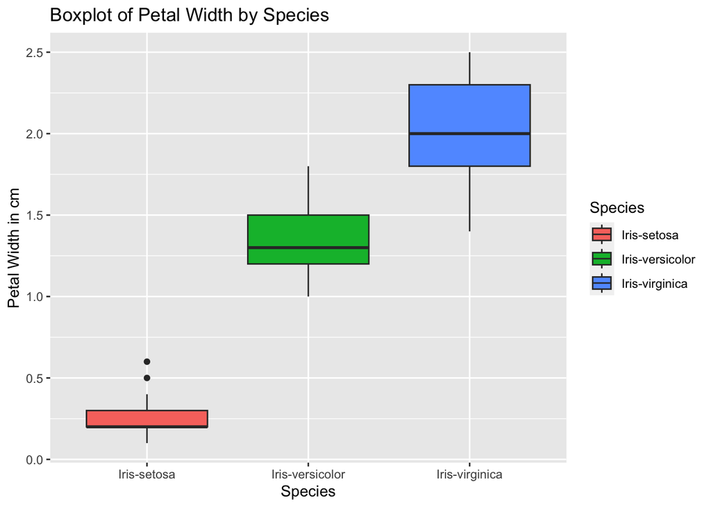

```r
ggplot(Iris, aes(x = Species, y = PetalWidthCm, fill = Species)) +
  geom_boxplot() +
  labs(x = "Species", y = "Petal Width in cm", title = "Boxplot of Petal Width by Species") +
  scale_fill_manual(values = c("#F8766D", "#00BA38", "#619CFF"))
```

## Make the histogram for Petal.Width with 3 species separately in x-axis in different colors

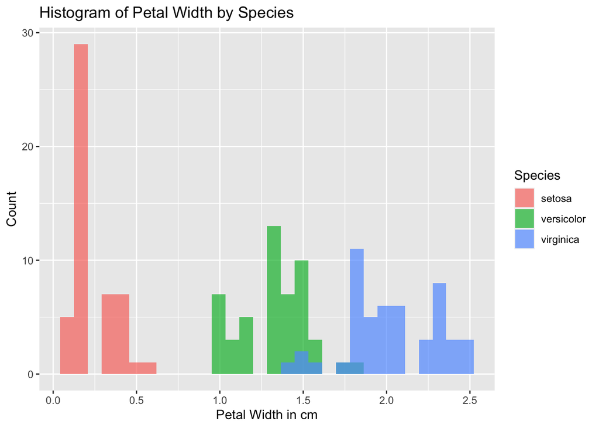

```r
ggplot(iris, aes(x = Petal.Width, fill = Species)) +
  geom_histogram(position = "identity", bins = 30, alpha = 0.7) +
  labs(x = "Petal Width in cm", y = "Count", title = "Histogram of Petal Width by Species") +
  scale_fill_manual(values = c("#F8766D", "#00BA38", "#619CFF"))
```

## Run the t-test of Petal.Width between setosa and virginica, and give the conclusion if the width is a statistically significant difference between 2 species

The output of the t.test() function will provide information about the t-statistic, degrees of freedom, the p-value, and whether the difference in means is statistically significant.

```r
setosa_width <- iris$Petal.Width[iris$Species == "setosa"]
virginica_width <- iris$Petal.Width[iris$Species == "virginica"]
t_test_result <- t.test(setosa_width, virginica_width)
t_test_result
```

```
##
##  Welch Two Sample t-test
##
## data:  setosa_width and virginica_width
## t = -42.786, df = 63.123, p-value < 2.2e-16
## alternative hypothesis: true difference in means is not equal to 0
## 95 percent confidence interval:
##  -1.863133 -1.696867
## sample estimates:
## mean of x mean of y
##     0.246     2.026
```

The Welch Two Sample t-test revealed a highly significant difference (t = -42.786, df = 63.123, p < 2.2e-16) in the mean Petal.Width between the Setosa and Virginica species. These findings provide strong evidence to reject the null hypothesis, indicating a statistically significant distinction in the Petal.Width between the two species. The Setosa species exhibited a mean Petal.Width of 0.246, while the Virginica species had a mean Petal.Width of 2.026. This result highlights the significant variation in Petal.Width, emphasizing its importance as a distinguishing feature between the Setosa and Virginica species.